# Risk Factor Analysis

## Outcome Variable

**Outcome Variable:** pers_wasted624

## Predictor Variables

**Intervention Variable:** ever_swasted06

**Adjustment Set:**

- sex
- arm
- brthmon
- vagbrth
- single
- W_mage
- W_mhtcm
- W_mwtkg
- W_mbmi
- W_meducyrs
- W_feducyrs
- W_parity
- delta_brthmon
- delta_vagbrth
- delta_single
- delta_W_mage
- delta_W_mhtcm
- delta_W_mwtkg
- delta_W_mbmi
- delta_W_meducyrs
- delta_W_feducyrs
- delta_W_parity

## Stratifying Variables

The analysis was stratified on these variable(s):

- studyid
- country

## Data Summary

| studyid | country | ever_swasted06 | pers_wasted624 | n_cell | n | outcome_variable |
| --- | --- | --- | --- | --- | --- | --- |
| CMC-V-BCS-2002 | INDIA | 0 | 0 | 287 | 370 | pers_wasted624 |
| CMC-V-BCS-2002 | INDIA | 0 | 1 | 14 | 370 | pers_wasted624 |
| CMC-V-BCS-2002 | INDIA | 1 | 0 | 55 | 370 | pers_wasted624 |
| CMC-V-BCS-2002 | INDIA | 1 | 1 | 14 | 370 | pers_wasted624 |
| CMIN | BANGLADESH | 0 | 0 | 221 | 252 | pers_wasted624 |
| CMIN | BANGLADESH | 0 | 1 | 20 | 252 | pers_wasted624 |
| CMIN | BANGLADESH | 1 | 0 | 6 | 252 | pers_wasted624 |
| CMIN | BANGLADESH | 1 | 1 | 5 | 252 | pers_wasted624 |
| COHORTS | GUATEMALA | 0 | 0 | 914 | 1017 | pers_wasted624 |
| COHORTS | GUATEMALA | 0 | 1 | 37 | 1017 | pers_wasted624 |
| COHORTS | GUATEMALA | 1 | 0 | 62 | 1017 | pers_wasted624 |
| COHORTS | GUATEMALA | 1 | 1 | 4 | 1017 | pers_wasted624 |
| COHORTS | INDIA | 0 | 0 | 5796 | 6892 | pers_wasted624 |
| COHORTS | INDIA | 0 | 1 | 488 | 6892 | pers_wasted624 |
| COHORTS | INDIA | 1 | 0 | 326 | 6892 | pers_wasted624 |
| COHORTS | INDIA | 1 | 1 | 282 | 6892 | pers_wasted624 |
| COHORTS | PHILIPPINES | 0 | 0 | 2431 | 2808 | pers_wasted624 |
| COHORTS | PHILIPPINES | 0 | 1 | 175 | 2808 | pers_wasted624 |
| COHORTS | PHILIPPINES | 1 | 0 | 151 | 2808 | pers_wasted624 |
| COHORTS | PHILIPPINES | 1 | 1 | 51 | 2808 | pers_wasted624 |
| CONTENT | PERU | 0 | 0 | 214 | 215 | pers_wasted624 |
| CONTENT | PERU | 0 | 1 | 0 | 215 | pers_wasted624 |
| CONTENT | PERU | 1 | 0 | 1 | 215 | pers_wasted624 |
| CONTENT | PERU | 1 | 1 | 0 | 215 | pers_wasted624 |
| EE | PAKISTAN | 0 | 0 | 298 | 374 | pers_wasted624 |
| EE | PAKISTAN | 0 | 1 | 37 | 374 | pers_wasted624 |
| EE | PAKISTAN | 1 | 0 | 27 | 374 | pers_wasted624 |
| EE | PAKISTAN | 1 | 1 | 12 | 374 | pers_wasted624 |
| GMS-Nepal | NEPAL | 0 | 0 | 433 | 590 | pers_wasted624 |
| GMS-Nepal | NEPAL | 0 | 1 | 83 | 590 | pers_wasted624 |

[output cut: 90 more lines]

The following strata were considered:

- studyid: CMC-V-BCS-2002, country: INDIA
- studyid: CMIN, country: BANGLADESH
- studyid: COHORTS, country: GUATEMALA
- studyid: COHORTS, country: INDIA
- studyid: COHORTS, country: PHILIPPINES
- studyid: CONTENT, country: PERU
- studyid: EE, country: PAKISTAN
- studyid: GMS-Nepal, country: NEPAL
- studyid: Guatemala BSC, country: GUATEMALA
- studyid: IRC, country: INDIA
- studyid: JiVitA-3, country: BANGLADESH
- studyid: JiVitA-4, country: BANGLADESH
- studyid: Keneba, country: GAMBIA
- studyid: LCNI-5, country: MALAWI
- studyid: MAL-ED, country: BANGLADESH
- studyid: MAL-ED, country: BRAZIL
- studyid: MAL-ED, country: INDIA
- studyid: MAL-ED, country: NEPAL
- studyid: MAL-ED, country: PERU
- studyid: MAL-ED, country: SOUTH AFRICA
- studyid: MAL-ED, country: TANZANIA, UNITED REPUBLIC OF
- studyid: NIH-Birth, country: BANGLADESH
- studyid: NIH-Crypto, country: BANGLADESH
- studyid: PROBIT, country: BELARUS
- studyid: PROVIDE, country: BANGLADESH
- studyid: ResPak, country: PAKISTAN
- studyid: SAS-CompFeed, country: INDIA
- studyid: SAS-FoodSuppl, country: INDIA
- studyid: TanzaniaChild2, country: TANZANIA, UNITED REPUBLIC OF
- studyid: ZVITAMBO, country: ZIMBABWE

### Dropped Strata

Some strata were dropped due to rare outcomes:

- studyid: COHORTS, country: GUATEMALA
- studyid: CONTENT, country: PERU
- studyid: Guatemala BSC, country: GUATEMALA
- studyid: LCNI-5, country: MALAWI
- studyid: MAL-ED, country: BANGLADESH
- studyid: MAL-ED, country: BRAZIL
- studyid: MAL-ED, country: NEPAL
- studyid: MAL-ED, country: PERU
- studyid: MAL-ED, country: SOUTH AFRICA
- studyid: MAL-ED, country: TANZANIA, UNITED REPUBLIC OF

## Methods Detail

We’re interested in the causal parameters $E[Y_a]$ for all values of $a \in \mathcal{A}$. These parameters represent the mean outcome if, possibly contrary to fact, we intervened to set all units to have $A=a$. Under the randomization and positivity assumptions, these are identified by the statistical parameters $\psi_a=E_W[E_{Y|A,W}(Y|A=a,W)]$. In addition, we’re interested in the mean of $Y$, $E[Y]$ under no intervention (the observed mean). We will estimate these parameters by using SuperLearner to fit the relevant likelihood factors – $E_{Y|A,W}(Y|A=a,W)$ and $p(A=a|W)$, and then updating our likelihood fit using a joint TMLE.

For unadjusted analyses ($W=\{\}$), initial likelihoods were estimated using Lrnr_glm to estimate the simple $E(Y|A)$ and Lrnr_mean to estimate $p(A)$. For adjusted analyses, a small library containing Lrnr_glmnet, Lrnr_xgboost, and Lrnr_mean was used.

Having estimated these parameters, we will then use the delta method to estimate relative risks and attributable risks relative to a prespecified baseline level of $A$.

[output not shown]

[output not shown]

[output not shown]

# Results Detail

## Results Plots

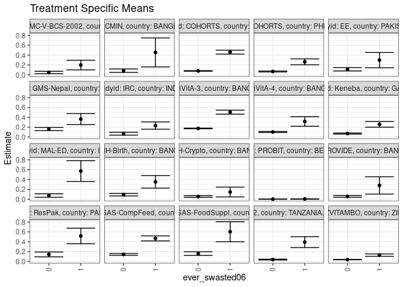

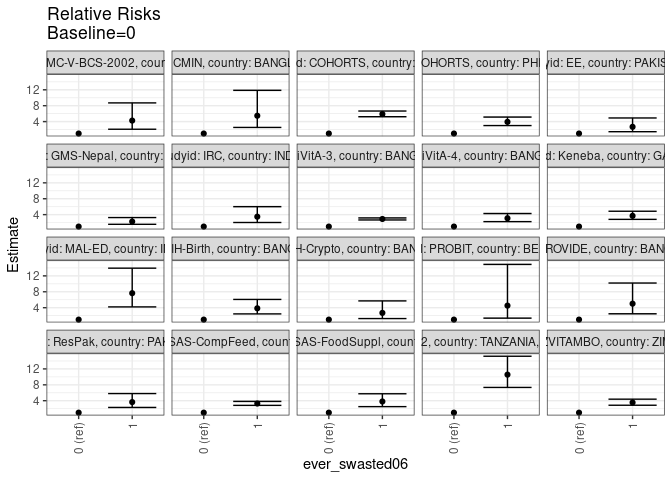

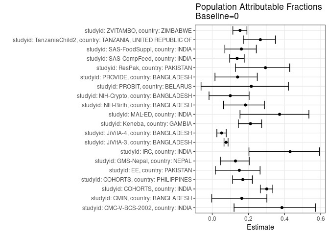

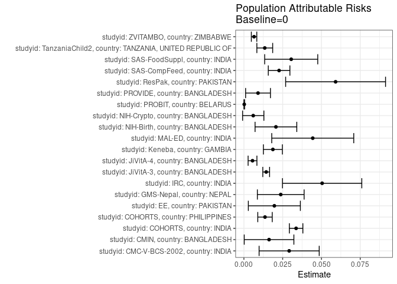

## Results Table

### Parameter: TSM

| studyid | country | intervention_level | baseline_level | estimate | ci_lower | ci_upper |
| --- | --- | --- | --- | --- | --- | --- |
| CMC-V-BCS-2002 | INDIA | 0 | NA | 0.0464957 | 0.0226319 | 0.0703595 |
| CMC-V-BCS-2002 | INDIA | 1 | NA | 0.1979569 | 0.0995978 | 0.2963159 |
| CMIN | BANGLADESH | 0 | NA | 0.0829876 | 0.0480898 | 0.1178853 |
| CMIN | BANGLADESH | 1 | NA | 0.4545455 | 0.1597077 | 0.7493832 |
| COHORTS | INDIA | 0 | NA | 0.0780632 | 0.0714204 | 0.0847060 |
| COHORTS | INDIA | 1 | NA | 0.4605649 | 0.4204173 | 0.5007125 |
| COHORTS | PHILIPPINES | 0 | NA | 0.0668756 | 0.0572800 | 0.0764711 |
| COHORTS | PHILIPPINES | 1 | NA | 0.2628716 | 0.2029329 | 0.3228102 |
| EE | PAKISTAN | 0 | NA | 0.1113863 | 0.0775177 | 0.1452549 |
| EE | PAKISTAN | 1 | NA | 0.2986530 | 0.1422539 | 0.4550522 |
| GMS-Nepal | NEPAL | 0 | NA | 0.1609954 | 0.1292878 | 0.1927031 |
| GMS-Nepal | NEPAL | 1 | NA | 0.3641854 | 0.2512200 | 0.4771507 |
| IRC | INDIA | 0 | NA | 0.0666393 | 0.0373855 | 0.0958931 |
| IRC | INDIA | 1 | NA | 0.2321504 | 0.1578553 | 0.3064454 |
| JiVitA-3 | BANGLADESH | 0 | NA | 0.1736321 | 0.1673499 | 0.1799144 |
| JiVitA-3 | BANGLADESH | 1 | NA | 0.5048453 | 0.4639830 | 0.5457077 |
| JiVitA-4 | BANGLADESH | 0 | NA | 0.1017214 | 0.0913559 | 0.1120868 |
| JiVitA-4 | BANGLADESH | 1 | NA | 0.3151844 | 0.2182198 | 0.4121489 |
| Keneba | GAMBIA | 0 | NA | 0.0696515 | 0.0587100 | 0.0805930 |
| Keneba | GAMBIA | 1 | NA | 0.2575486 | 0.1995831 | 0.3155141 |
| MAL-ED | INDIA | 0 | NA | 0.0747664 | 0.0394524 | 0.1100803 |
| MAL-ED | INDIA | 1 | NA | 0.5714286 | 0.3593206 | 0.7835366 |
| NIH-Birth | BANGLADESH | 0 | NA | 0.0919010 | 0.0663158 | 0.1174861 |
| NIH-Birth | BANGLADESH | 1 | NA | 0.3530632 | 0.2256321 | 0.4804943 |
| NIH-Crypto | BANGLADESH | 0 | NA | 0.0542522 | 0.0372404 | 0.0712640 |
| NIH-Crypto | BANGLADESH | 1 | NA | 0.1458333 | 0.0459197 | 0.2457470 |
| PROBIT | BELARUS | 0 | NA | 0.0008500 | 0.0002192 | 0.0014809 |
| PROBIT | BELARUS | 1 | NA | 0.0038402 | 0.0006414 | 0.0070391 |
| PROVIDE | BANGLADESH | 0 | NA | 0.0559322 | 0.0373752 | 0.0744892 |
| PROVIDE | BANGLADESH | 1 | NA | 0.2800000 | 0.1038524 | 0.4561476 |
| ResPak | PAKISTAN | 0 | NA | 0.1417417 | 0.0925546 | 0.1909288 |
| ResPak | PAKISTAN | 1 | NA | 0.5177198 | 0.3596050 | 0.6758346 |
| SAS-CompFeed | INDIA | 0 | NA | 0.1420534 | 0.1233964 | 0.1607105 |
| SAS-CompFeed | INDIA | 1 | NA | 0.4675790 | 0.4163751 | 0.5187830 |
| SAS-FoodSuppl | INDIA | 0 | NA | 0.1585566 | 0.1214290 | 0.1956843 |
| SAS-FoodSuppl | INDIA | 1 | NA | 0.6034299 | 0.3989064 | 0.8079535 |
| TanzaniaChild2 | TANZANIA, UNITED REPUBLIC OF | 0 | NA | 0.0370925 | 0.0286831 | 0.0455019 |
| TanzaniaChild2 | TANZANIA, UNITED REPUBLIC OF | 1 | NA | 0.3916424 | 0.2803490 | 0.5029358 |
| ZVITAMBO | ZIMBABWE | 0 | NA | 0.0360330 | 0.0323796 | 0.0396863 |
| ZVITAMBO | ZIMBABWE | 1 | NA | 0.1277601 | 0.1038889 | 0.1516313 |

### Parameter: E(Y)

| studyid | country | intervention_level | baseline_level | estimate | ci_lower | ci_upper |
| --- | --- | --- | --- | --- | --- | --- |
| CMC-V-BCS-2002 | INDIA | NA | NA | 0.0756757 | 0.0486905 | 0.1026609 |
| CMIN | BANGLADESH | NA | NA | 0.0992063 | 0.0622241 | 0.1361886 |
| COHORTS | INDIA | NA | NA | 0.1117237 | 0.1042858 | 0.1191617 |
| COHORTS | PHILIPPINES | NA | NA | 0.0804843 | 0.0704205 | 0.0905481 |
| EE | PAKISTAN | NA | NA | 0.1310160 | 0.0967738 | 0.1652583 |
| GMS-Nepal | NEPAL | NA | NA | 0.1847458 | 0.1534039 | 0.2160876 |
| IRC | INDIA | NA | NA | 0.1170732 | 0.0859146 | 0.1482317 |
| JiVitA-3 | BANGLADESH | NA | NA | 0.1880070 | 0.1814627 | 0.1945512 |
| JiVitA-4 | BANGLADESH | NA | NA | 0.1072724 | 0.0967392 | 0.1178055 |
| Keneba | GAMBIA | NA | NA | 0.0883377 | 0.0767324 | 0.0999430 |
| MAL-ED | INDIA | NA | NA | 0.1191489 | 0.0776405 | 0.1606574 |
| NIH-Birth | BANGLADESH | NA | NA | 0.1125461 | 0.0859151 | 0.1391771 |
| NIH-Crypto | BANGLADESH | NA | NA | 0.0602740 | 0.0429977 | 0.0775502 |
| PROBIT | BELARUS | NA | NA | 0.0010846 | 0.0004977 | 0.0016715 |
| PROVIDE | BANGLADESH | NA | NA | 0.0650407 | 0.0455353 | 0.0845460 |
| ResPak | PAKISTAN | NA | NA | 0.2008547 | 0.1494120 | 0.2522974 |
| SAS-CompFeed | INDIA | NA | NA | 0.1647399 | 0.1451050 | 0.1843747 |
| SAS-FoodSuppl | INDIA | NA | NA | 0.1890547 | 0.1507312 | 0.2273783 |
| TanzaniaChild2 | TANZANIA, UNITED REPUBLIC OF | NA | NA | 0.0505451 | 0.0409848 | 0.0601054 |
| ZVITAMBO | ZIMBABWE | NA | NA | 0.0425869 | 0.0387663 | 0.0464075 |

### Parameter: RR

| studyid | country | intervention_level | baseline_level | estimate | ci_lower | ci_upper |
| --- | --- | --- | --- | --- | --- | --- |
| CMC-V-BCS-2002 | INDIA | 0 | 0 | 1.000000 | 1.000000 | 1.000000 |
| CMC-V-BCS-2002 | INDIA | 1 | 0 | 4.257532 | 2.081275 | 8.709363 |
| CMIN | BANGLADESH | 0 | 0 | 1.000000 | 1.000000 | 1.000000 |
| CMIN | BANGLADESH | 1 | 0 | 5.477273 | 2.528380 | 11.865507 |
| COHORTS | INDIA | 0 | 0 | 1.000000 | 1.000000 | 1.000000 |
| COHORTS | INDIA | 1 | 0 | 5.899901 | 5.225117 | 6.661827 |
| COHORTS | PHILIPPINES | 0 | 0 | 1.000000 | 1.000000 | 1.000000 |
| COHORTS | PHILIPPINES | 1 | 0 | 3.930756 | 3.005249 | 5.141287 |
| EE | PAKISTAN | 0 | 0 | 1.000000 | 1.000000 | 1.000000 |
| EE | PAKISTAN | 1 | 0 | 2.681237 | 1.462191 | 4.916617 |
| GMS-Nepal | NEPAL | 0 | 0 | 1.000000 | 1.000000 | 1.000000 |
| GMS-Nepal | NEPAL | 1 | 0 | 2.262085 | 1.566554 | 3.266424 |
| IRC | INDIA | 0 | 0 | 1.000000 | 1.000000 | 1.000000 |
| IRC | INDIA | 1 | 0 | 3.483687 | 2.021231 | 6.004297 |
| JiVitA-3 | BANGLADESH | 0 | 0 | 1.000000 | 1.000000 | 1.000000 |
| JiVitA-3 | BANGLADESH | 1 | 0 | 2.907557 | 2.664572 | 3.172701 |
| JiVitA-4 | BANGLADESH | 0 | 0 | 1.000000 | 1.000000 | 1.000000 |
| JiVitA-4 | BANGLADESH | 1 | 0 | 3.098507 | 2.245351 | 4.275832 |
| Keneba | GAMBIA | 0 | 0 | 1.000000 | 1.000000 | 1.000000 |
| Keneba | GAMBIA | 1 | 0 | 3.697676 | 2.811996 | 4.862313 |
| MAL-ED | INDIA | 0 | 0 | 1.000000 | 1.000000 | 1.000000 |
| MAL-ED | INDIA | 1 | 0 | 7.642857 | 4.191447 | 13.936300 |
| NIH-Birth | BANGLADESH | 0 | 0 | 1.000000 | 1.000000 | 1.000000 |
| NIH-Birth | BANGLADESH | 1 | 0 | 3.841778 | 2.432164 | 6.068363 |
| NIH-Crypto | BANGLADESH | 0 | 0 | 1.000000 | 1.000000 | 1.000000 |
| NIH-Crypto | BANGLADESH | 1 | 0 | 2.688063 | 1.265352 | 5.710413 |
| PROBIT | BELARUS | 0 | 0 | 1.000000 | 1.000000 | 1.000000 |
| PROBIT | BELARUS | 1 | 0 | 4.517901 | 1.371594 | 14.881545 |
| PROVIDE | BANGLADESH | 0 | 0 | 1.000000 | 1.000000 | 1.000000 |
| PROVIDE | BANGLADESH | 1 | 0 | 5.006061 | 2.458188 | 10.194764 |
| ResPak | PAKISTAN | 0 | 0 | 1.000000 | 1.000000 | 1.000000 |
| ResPak | PAKISTAN | 1 | 0 | 3.652558 | 2.300891 | 5.798267 |
| SAS-CompFeed | INDIA | 0 | 0 | 1.000000 | 1.000000 | 1.000000 |
| SAS-CompFeed | INDIA | 1 | 0 | 3.291571 | 2.830117 | 3.828266 |
| SAS-FoodSuppl | INDIA | 0 | 0 | 1.000000 | 1.000000 | 1.000000 |
| SAS-FoodSuppl | INDIA | 1 | 0 | 3.805769 | 2.517558 | 5.753146 |
| TanzaniaChild2 | TANZANIA, UNITED REPUBLIC OF | 0 | 0 | 1.000000 | 1.000000 | 1.000000 |
| TanzaniaChild2 | TANZANIA, UNITED REPUBLIC OF | 1 | 0 | 10.558533 | 7.341776 | 15.184695 |
| ZVITAMBO | ZIMBABWE | 0 | 0 | 1.000000 | 1.000000 | 1.000000 |
| ZVITAMBO | ZIMBABWE | 1 | 0 | 3.545646 | 2.867494 | 4.384177 |

### Parameter: PAR

| studyid | country | intervention_level | baseline_level | estimate | ci_lower | ci_upper |
| --- | --- | --- | --- | --- | --- | --- |
| CMC-V-BCS-2002 | INDIA | 0 | NA | 0.0291800 | 0.0098032 | 0.0485567 |
| CMIN | BANGLADESH | 0 | NA | 0.0162188 | 0.0002139 | 0.0322237 |
| COHORTS | INDIA | 0 | NA | 0.0336606 | 0.0293057 | 0.0380154 |
| COHORTS | PHILIPPINES | 0 | NA | 0.0136088 | 0.0089516 | 0.0182659 |
| EE | PAKISTAN | 0 | NA | 0.0196298 | 0.0028606 | 0.0363989 |
| GMS-Nepal | NEPAL | 0 | NA | 0.0237503 | 0.0086814 | 0.0388193 |
| IRC | INDIA | 0 | NA | 0.0504339 | 0.0248678 | 0.0760000 |
| JiVitA-3 | BANGLADESH | 0 | NA | 0.0143748 | 0.0121863 | 0.0165634 |
| JiVitA-4 | BANGLADESH | 0 | NA | 0.0055510 | 0.0027163 | 0.0083857 |
| Keneba | GAMBIA | 0 | NA | 0.0186862 | 0.0125597 | 0.0248127 |
| MAL-ED | INDIA | 0 | NA | 0.0443826 | 0.0179485 | 0.0708166 |
| NIH-Birth | BANGLADESH | 0 | NA | 0.0206451 | 0.0071943 | 0.0340960 |
| NIH-Crypto | BANGLADESH | 0 | NA | 0.0060218 | -0.0008431 | 0.0128867 |
| PROBIT | BELARUS | 0 | NA | 0.0002346 | 0.0000115 | 0.0004577 |
| PROVIDE | BANGLADESH | 0 | NA | 0.0091084 | 0.0011028 | 0.0171141 |
| ResPak | PAKISTAN | 0 | NA | 0.0591130 | 0.0269152 | 0.0913108 |
| SAS-CompFeed | INDIA | 0 | NA | 0.0226864 | 0.0157236 | 0.0296493 |
| SAS-FoodSuppl | INDIA | 0 | NA | 0.0304981 | 0.0133889 | 0.0476072 |
| TanzaniaChild2 | TANZANIA, UNITED REPUBLIC OF | 0 | NA | 0.0134526 | 0.0083514 | 0.0185538 |
| ZVITAMBO | ZIMBABWE | 0 | NA | 0.0065539 | 0.0048005 | 0.0083073 |

### Parameter: PAF

| studyid | country | intervention_level | baseline_level | estimate | ci_lower | ci_upper |
| --- | --- | --- | --- | --- | --- | --- |
| CMC-V-BCS-2002 | INDIA | 0 | NA | 0.3855926 | 0.1207242 | 0.5706735 |
| CMIN | BANGLADESH | 0 | NA | 0.1634855 | -0.0027793 | 0.3021829 |
| COHORTS | INDIA | 0 | NA | 0.3012840 | 0.2658663 | 0.3349930 |
| COHORTS | PHILIPPINES | 0 | NA | 0.1690859 | 0.1125766 | 0.2219967 |
| EE | PAKISTAN | 0 | NA | 0.1498272 | 0.0169684 | 0.2647298 |
| GMS-Nepal | NEPAL | 0 | NA | 0.1285568 | 0.0450425 | 0.2047675 |
| IRC | INDIA | 0 | NA | 0.4307895 | 0.2031345 | 0.5934061 |
| JiVitA-3 | BANGLADESH | 0 | NA | 0.0764591 | 0.0652127 | 0.0875702 |
| JiVitA-4 | BANGLADESH | 0 | NA | 0.0517468 | 0.0254621 | 0.0773226 |
| Keneba | GAMBIA | 0 | NA | 0.2115315 | 0.1443306 | 0.2734547 |
| MAL-ED | INDIA | 0 | NA | 0.3724967 | 0.1536730 | 0.5347420 |
| NIH-Birth | BANGLADESH | 0 | NA | 0.1834371 | 0.0623079 | 0.2889191 |
| NIH-Crypto | BANGLADESH | 0 | NA | 0.0999067 | -0.0178485 | 0.2040388 |
| PROBIT | BELARUS | 0 | NA | 0.2162940 | -0.0619533 | 0.4216364 |
| PROVIDE | BANGLADESH | 0 | NA | 0.1400424 | 0.0151570 | 0.2490913 |
| ResPak | PAKISTAN | 0 | NA | 0.2943072 | 0.1285778 | 0.4285177 |
| SAS-CompFeed | INDIA | 0 | NA | 0.1377107 | 0.0965102 | 0.1770323 |
| SAS-FoodSuppl | INDIA | 0 | NA | 0.1613189 | 0.0698896 | 0.2437607 |
| TanzaniaChild2 | TANZANIA, UNITED REPUBLIC OF | 0 | NA | 0.2661503 | 0.1719516 | 0.3496329 |
| ZVITAMBO | ZIMBABWE | 0 | NA | 0.1538955 | 0.1140123 | 0.1919833 |